# lab3

Zeren Li

9/11/2019

## Roadmap

- OLS
- `ggplot`

## OLS

$$Y_i = beta_0 + beta_1 X_i + u_i$$

where - the index $i$ runs over the observations, $i=1,\dots,n$ - $Y_i$ is the *dependent variable*, the *regressand*, or simply the *left-hand variable* - $X_i$ is the *independent variable*, the *regressor*, or simply the *right-hand variable* - $Y = \beta_0 + \beta_1 X$ is the *population regression line* also called the *population regression function* - $\beta_0$ is the *intercept* of the population regression line - $\beta_1$ is the *slope* of the population regression line - $u_i$ is the *error term*.

## Returns to Peformance

```r
summary(ceo)
```

```
##      salary            age           college            grad
##  Min.   : 100.0   Min.   :33.00   Min.   :0.0000   Min.   :0.0000
##  1st Qu.: 471.0   1st Qu.:52.00   1st Qu.:1.0000   1st Qu.:0.0000
##  Median : 707.0   Median :57.00   Median :1.0000   Median :1.0000
##  Mean   : 865.9   Mean   :56.43   Mean   :0.9718   Mean   :0.5311
##  3rd Qu.:1119.0   3rd Qu.:62.00   3rd Qu.:1.0000   3rd Qu.:1.0000
##  Max.   :5299.0   Max.   :86.00   Max.   :1.0000   Max.   :1.0000
##      comten         ceoten           sales          profits
##  Min.   : 2.0   Min.   : 0.000   Min.   :   29   Min.   :-463.0
##  1st Qu.:12.0   1st Qu.: 3.000   1st Qu.:  561   1st Qu.:  34.0
##  Median :23.0   Median : 6.000   Median : 1400   Median :  63.0
##  Mean   :22.5   Mean   : 7.955   Mean   : 3529   Mean   : 207.8
##  3rd Qu.:33.0   3rd Qu.:11.000   3rd Qu.: 3500   3rd Qu.: 208.0
##  Max.   :58.0   Max.   :37.000   Max.   :51300   Max.   :2700.0
##      mktval         lsalary          lsales          lmktval
##  Min.   :  387   Min.   :4.605   Min.   : 3.367   Min.   : 5.958
##  1st Qu.:  644   1st Qu.:6.155   1st Qu.: 6.330   1st Qu.: 6.468
##  Median : 1200   Median :6.561   Median : 7.244   Median : 7.090
##  Mean   : 3600   Mean   :6.583   Mean   : 7.231   Mean   : 7.399
##  3rd Qu.: 3500   3rd Qu.:7.020   3rd Qu.: 8.161   3rd Qu.: 8.161
##  Max.   :45400   Max.   :8.575   Max.   :10.845   Max.   :10.723
##     comtensq         ceotensq         profmarg
##  Min.   :   4.0   Min.   :   0.0   Min.   :-203.077
##  1st Qu.: 144.0   1st Qu.:   9.0   1st Qu.:   4.231
##  Median : 529.0   Median :  36.0   Median :   6.834
##  Mean   : 656.7   Mean   : 114.1   Mean   :   6.420
##  3rd Qu.:1089.0   3rd Qu.: 121.0   3rd Qu.:  10.947
##  Max.   :3364.0   Max.   :1369.0   Max.   :  47.458
```

## Visualization

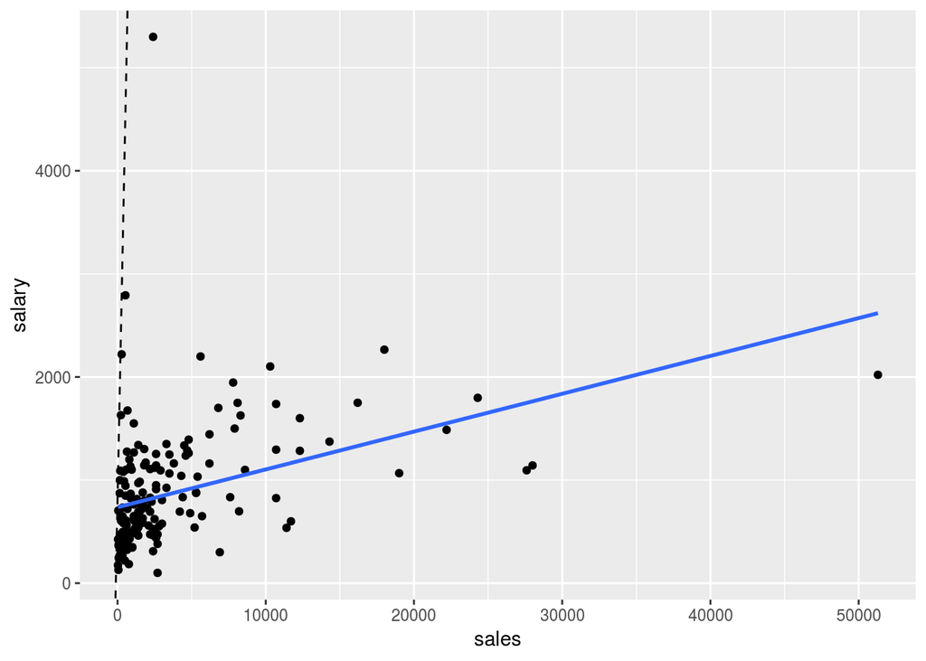

```r
ggplot(ceo, aes(x = sales, y = salary)) +
  geom_point() +
  geom_smooth(method = "lm", se = FALSE) +
  geom_abline(slope = 7.06, intercept = 811.23, linetype = "dashed")
```

## Data Visualization using `ggplot2`

### Overview

ggplot2 is a system for declaratively creating graphics, based on The Grammar of Graphics. You provide the data, tell ggplot2 how to map variables to aesthetics, what graphical primitives to use, and it takes care of the details.

### Terminology

A statistical graphic is a…

- mapping of **data**
- which may be **statistically transformed** (summarised, log-transformed, etc.)
- to **aesthetic attributes** (color, size, xy-position, etc.)
- using **geometric objects** (points, lines, bars, etc.)
- and mapped onto a specific **facet** and **coordinate system**

### Ask yourself these questions before using `ggplot()`

- Which data is used as an input?
- Are the variables statistically transformed before plotting?
- What geometric objects are used to represent the data?
- What variables are mapped onto which aesthetic attributes?
- What type of scales are used to map data to aesthetics?

### Anatomy of a ggplot

```r
ggplot(
  data = [dataframe],
  aes(
    x = [var_x], y = [var_y],
    color = [var_for_color],
    fill = [var_for_fill],
    shape = [var_for_shape]
  )
) +
  geom_[some_geom]([geom_arguments]) +
  ... # other geometries
  scale_[some_axis]_[some_scale]() +
  facet_[some_facet]([formula]) +
  ... # other options
```

### Distribution

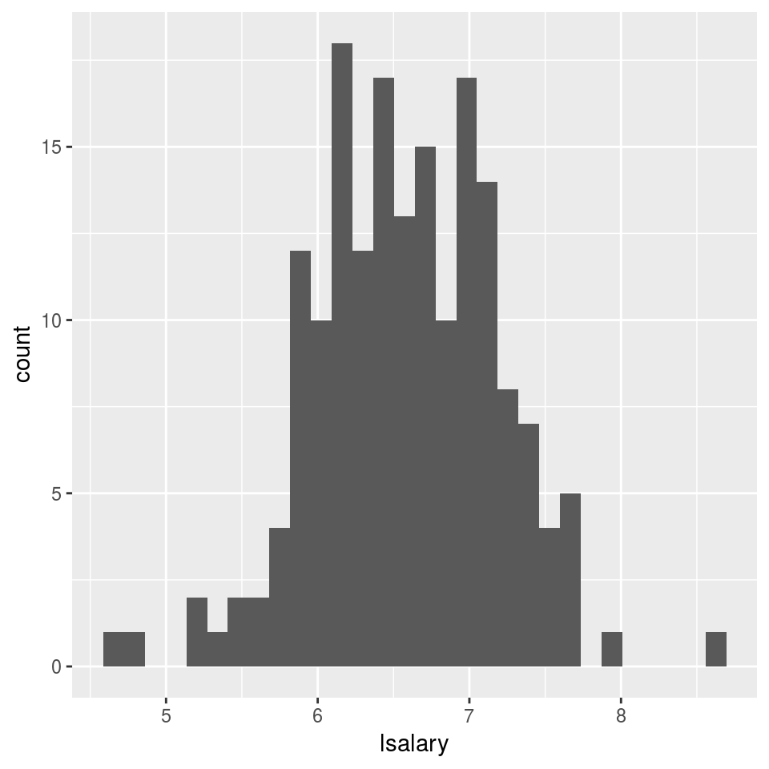

```r
ggplot(data = ceo, aes(x = lsalary))  +
    geom_histogram()
```

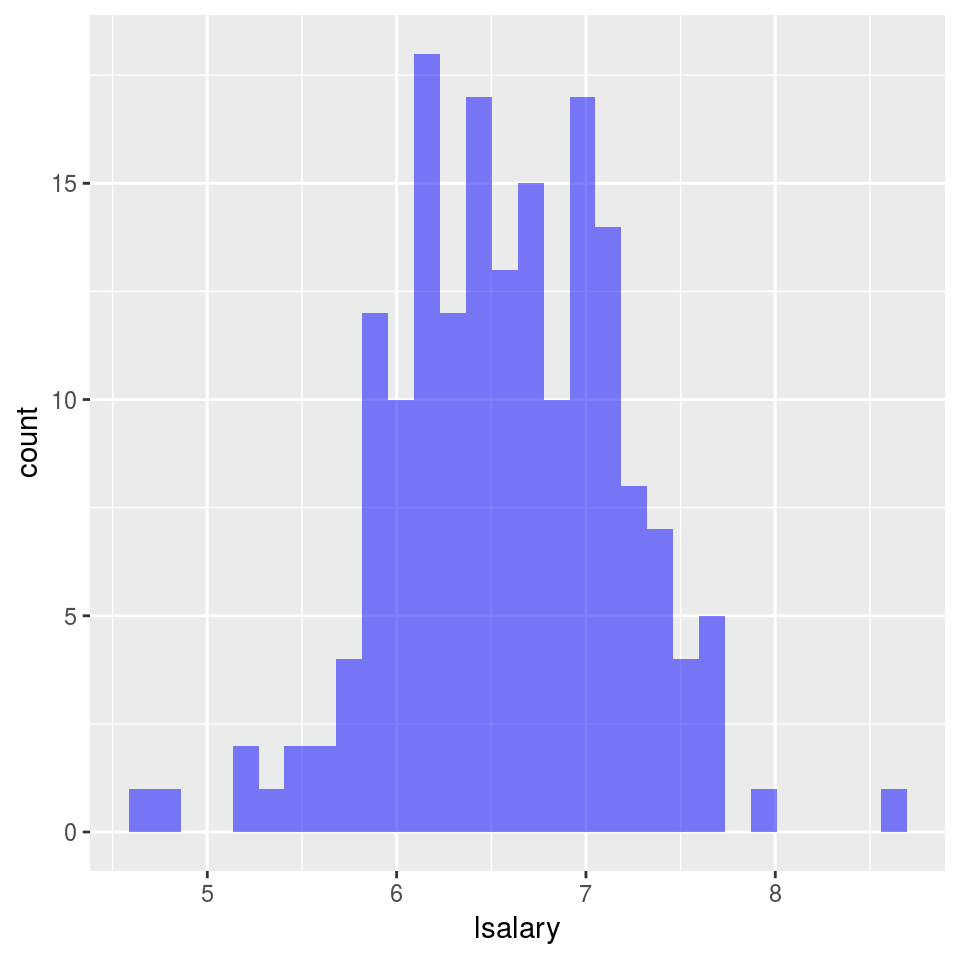

```r
ggplot(data = ceo, aes(x = lsalary))  +
  geom_histogram(alpha = .5, fill = "blue")
```

### Distribution

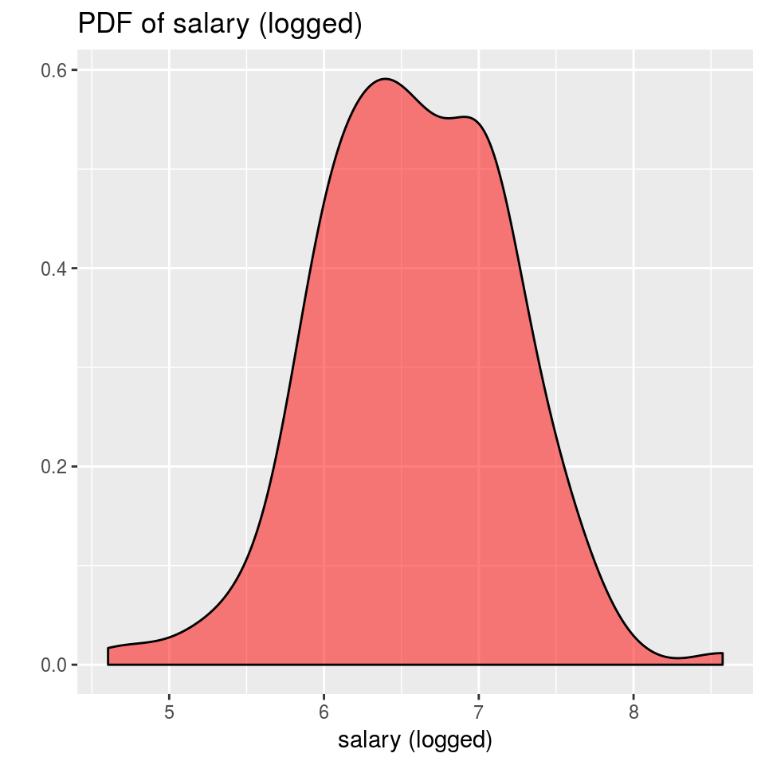

```r
ggplot(data = ceo, aes(x = lsalary))  +
    geom_density(fill = "red", alpha = .5)  +
    xlab("salary (logged)") +
    ylab("") +
    ggtitle("PDF of salary (logged)")
```

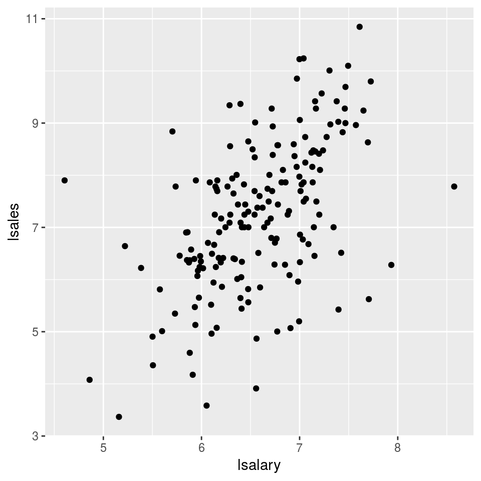

```r
ggsave("./hist.pdf")
ggplot(data = ceo, aes(x = lsalary, y = lsales)) +
  geom_point()
```

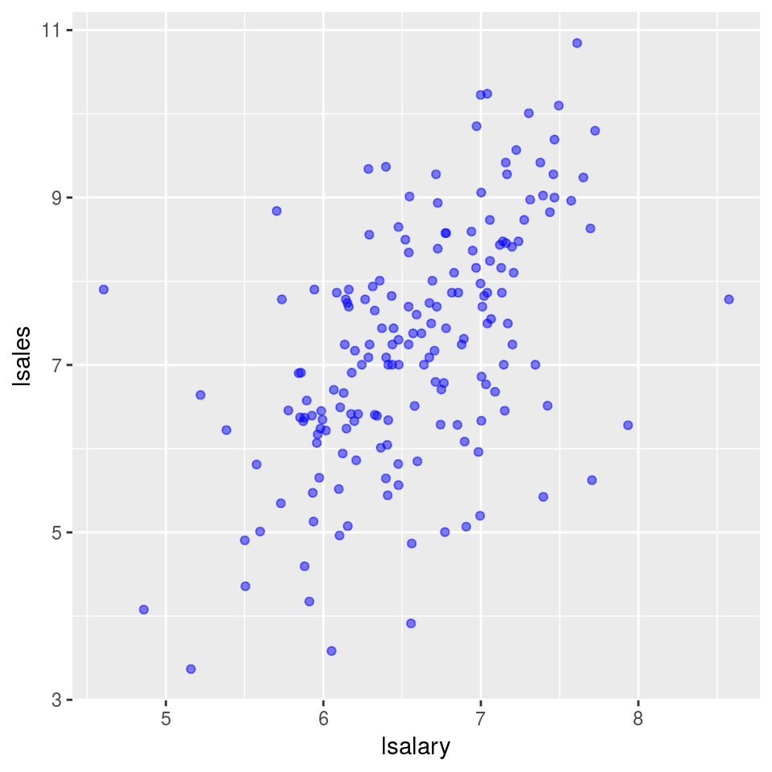

```r
ggplot(data = ceo, aes(x = lsalary, y = lsales)) +
  # specify some features
  geom_point(alpha = 0.5, color = "blue")
```

### Bar plot

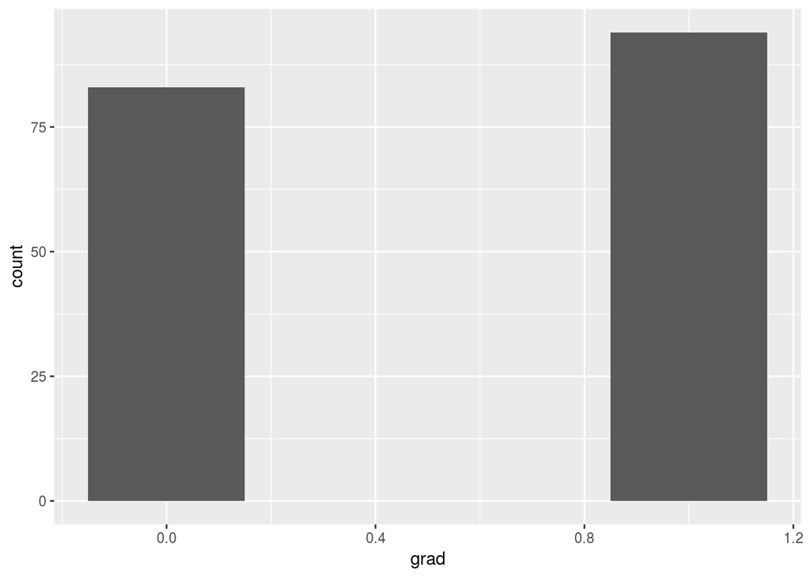

```r
ggplot(data = ceo, aes(x = grad )) +
  geom_bar(width = .3)
```

### Bar plot

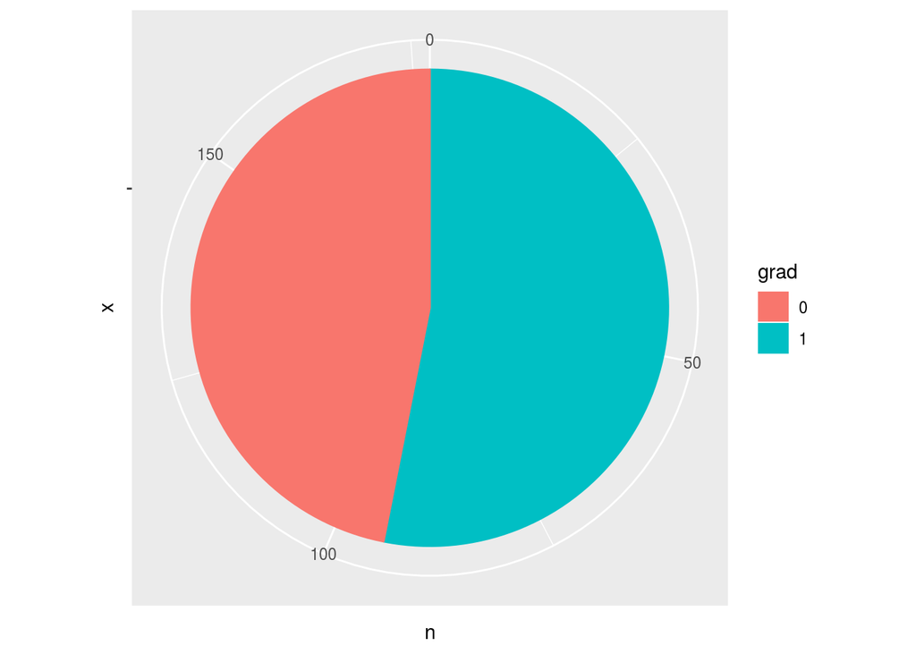

```r
# compute mean of salary first
ceo_grad_sum <- ceo %>%
                mutate(grad = as.factor(grad)) %>%
                    group_by(grad) %>%
                    summarize(n = n())

ggplot(data = ceo_grad_sum, aes(x = "", y = n, fill = grad, color = grad) )+
geom_bar(width = 1, stat = "identity")+
  coord_polar("y", start=0)
```

### Line plot - CEO work experience and salary

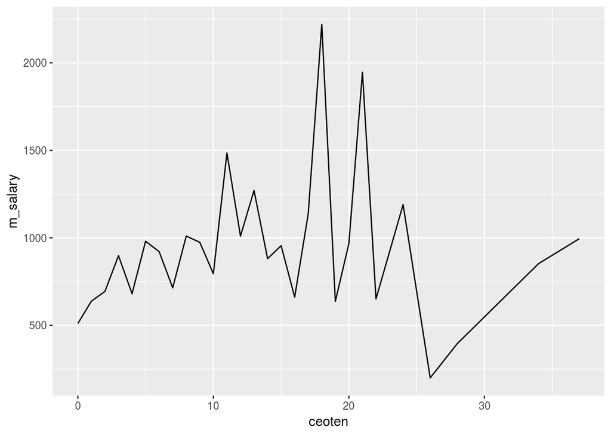

```r
# compute mean of salary first
ceo_sum <- ceo %>%
                group_by(ceoten) %>%
                summarise(m_salary = mean(salary, na.rm = T))

ggplot(data = ceo_sum, aes(x = ceoten, y = m_salary )) +
  geom_line()
```

## Resource

ggplot website: https://ggplot2.tidyverse.org/ cheatsheet:https://github.com/rstudio/cheatsheets/blob/master/data-visualization-2.1.pdf top 50 visualization: http://r-statistics.co/Top50-Ggplot2-Visualizations-MasterList-R-Code.html